# Προβλεπτική Αναλυτική

Ευαγγελιδάκης Λέανδρος, me1924

Μάρτιος 2020

## Εργαστηριακή Άσκηση 1

## Άσκηση 1

Ο όγκος σφαίρας ακτίνας R δίνεται από τον τύπο $\frac{4}{3}*π*R^3$. Για σφαίρες με ακτίνες 3, 4, 5,…,20 να βρείτε τον αντίστοιχο όγκο χρησιμοποιώντας το βρόγχο for. Επαναλάβετε με χρήση διανυσμάτων.

Λύση

```r
ex1<-function(r){

  #Using for loop
  volumes<-c()
  i<-1
  for (rad  in r) {
    vol<-(4/3)*pi*(rad^3)
    volumes[i]<-vol
    i<-i+1

  }
  print('Using for loop')
  print(volumes)

  #Using vectors
  print('Using vectors')
  volumes<-(4/3)*pi*r^3
  print(volumes)
}

ex1(3:20)
```

```
[1] "Using for loop"
 [1]   113.0973   268.0826   523.5988   904.7787  1436.7550  2144.6606
 [7]  3053.6281  4188.7902  5575.2798  7238.2295  9202.7721 11494.0403
[13] 14137.1669 17157.2847 20579.5263 24429.0245 28730.9120 33510.3216
[1] "Using vectors"
 [1]   113.0973   268.0826   523.5988   904.7787  1436.7550  2144.6606
 [7]  3053.6281  4188.7902  5575.2798  7238.2295  9202.7721 11494.0403
[13] 14137.1669 17157.2847 20579.5263 24429.0245 28730.9120 33510.3216
```

## Άσκηση 2

Πολλαπλασιάστε όλους τους αριθμούς από το 1 μέχρι και το 200 χρησιμοποιώντας τον βρόγχο for. Επαναλάβετε με τη βοήθεια της εντολής prod.

Λύση

```r
ex2<-function(r){

  p<-1
  for (i in r){
    p<-p*i
  }
  print(paste("Product using for loop:", p ))
  print(paste("Product using prod:", prod(r) ))

}
ex2(1:200)
```

```
[1] "Product using for loop: Inf"
[1] "Product using prod: Inf"
```

## Άσκηση 3

Εισάγετε στην R το παρακάτω διάνυσμα: 2, 3, 1, 5, 6, 3, 2, 5, 7, 9, 10, 11, 9, 8 Βρείτε το μήκος του διανύσματος, την ελάχιστη και μέγιστη τιμή του. Ταξινομήστε το κατά αύξουσα τάξη μεγέθους και δώστε τη σειρά κατάταξης τιμών. Χρησιμοποιήστε όλους τους τρόπους που διδαχθήκατε στις περιπτώσεις ισοπαλιών.

Λύση

```r
ex3<-function(input){

  print(paste("Length:", length(input) ))
  print(paste("Min:", min(input) ))
  print(paste("Max", max(input) ))
  print('Sorted vector:')
  print(sort(input))
  print('Order:')
  print(order(input))

}

input<-c(2,3,1,5,6,3,2,5,7,9,10,11,9,8)
ex3(input)
```

```
[1] "Length: 14"
[1] "Min: 1"
[1] "Max 11"
[1] "Sorted vector:"
 [1]  1  2  2  3  3  5  5  6  7  8  9  9 10 11
[1] "Order:"
 [1]  3  1  7  2  6  4  8  5  9 14 10 13 11 12
```

## Άσκηση 4

Δημιουργήστε μια συνάρτηση η οποία θα δέχεται ως όρισμα ένα διάνυσμα x, εν συνεχεία θα το ταξινομεί κατά αύξουσα τάξη μεγέθους και θα υπολογίζει τη διάμεσο.

Λύση

```r
ex4<-function(x){

  sorted<-sort(x)
  print('Input vector:')
  print(x)
  print('Sorted vector:')
  print(sorted)
  print('Median:')
  print(median(sorted))


}

x<-c(3,5,8,1,3,4,7,8,11,14,1,5)
ex4(x)
```

```
[1] "Input vector:"
 [1]  3  5  8  1  3  4  7  8 11 14  1  5
[1] "Sorted vector:"
 [1]  1  1  3  3  4  5  5  7  8  8 11 14
[1] "Median:"
[1] 5
```

## Άσκηση 5

Δημιουργήστε μια συνάρτηση η οποία θα δέχεται ως όρισμα έναν τετραγωνικό πίνακα Χ. Αν ο πίνακας δεν είναι τετραγωνικός θα επιστρέφει μήνυμα λάθους όπως και αν ο πίνακας δεν αντιστρέφεται αλλιώς σε μια λίστα θα επιστρέφει την ορίζουσα και τον αντίστροφο του πίνακα.

Λύση

```r
ex5<-function(matrix){

  if (dim(matrix)[1]==dim(matrix)[2]){
    print('Matrix is square')
  }
  else{
    print('ERROR.Matrix is not square')
  }
  det<-det(matrix)
  if (det==0){
    print('Matrix is not invertible')
  }
  else{
    print('Matrix is invertible')
    inv<-solve(matrix)
    output<-list(det,inv)

    print(paste('Determinant:',output[1]))
    print('Inverted Matrix:')
    print(output[2])

    }
}
```

Εφαρμόζουμε τη συνάρτηση για τον πίνακα [3x3]:

```r
table<-matrix(c(0.1964354,-0.6738396,-0.5938514,-0.8700559,-0.5422208,-1.1817128,
-0.6262798,1.2554072,0.2279084),nrow=3)
print('Original matrix:')
```

```
[1] "Original matrix:"
```

```r
print(table)
```

```
           [,1]       [,2]       [,3]
[1,]  0.1964354 -0.8700559 -0.6262798
[2,] -0.6738396 -0.5422208  1.2554072
[3,] -0.5938514 -1.1817128  0.2279084
```

```r
ex5(table)
```

```
[1] "Matrix is square"
[1] "Matrix is invertible"
[1] "Determinant: 0.485138193445903"
[1] "Inverted Matrix:"
[[1]]
           [,1]       [,2]       [,3]
[1,]  2.8032303  1.9342445 -2.9514402
[2,] -1.2201711 -0.6743395  0.3615582
[3,]  0.9776313  1.5435069 -1.4280250
```

## Άσκηση 6

Θεωρούμε το σύστημα

Να βρεθεί ο αντιστροφος και ο ανάστροφος αν υπάρχει Συνενώστε το διάνυσμα b σαν μία τέταρτη στήλη στον πίνακα Α. Καταχωρήστε το αποτέλεσμα αυτό στον πίνακα Α. Βρείτε τη λύση του συστήματος με χρήση της solve()

Λύση

```r
ex6<-function(A){

  print('Coefficient matrix')
  print(A)
  det<-det(A)

  if(det!=0){
    print('Matrix is invertible')
    print('Inverted matrix:')
    inv<-solve(A)
    print(inv)
    print('Transposed matrix:')
    print(t(A))
    b<-c(0,6,-1)
    A<-cbind(A,c(0,6,-1))
    print('Augmented matrix:')
    print(A)
    print('Solution of the system of equations:')
    print(solve(A[1:3,1:3],A[,4]))
  }
}

A<-c(5,-3,-2,3,-7,1,-3,-2,-2)
A<-matrix(A,nrow=3)
ex6(A)
```

```
[1] "Coefficient matrix"
     [,1] [,2] [,3]
[1,]    5    3   -3
[2,]   -3   -7   -2
[3,]   -2    1   -2
[1] "Matrix is invertible"
[1] "Inverted matrix:"
       [,1]   [,2]   [,3]
[1,]  0.128  0.024 -0.216
[2,] -0.016 -0.128  0.152
[3,] -0.136 -0.088 -0.208
[1] "Transposed matrix:"
     [,1] [,2] [,3]
[1,]    5   -3   -2
[2,]    3   -7    1
[3,]   -3   -2   -2
[1] "Augmented matrix:"
     [,1] [,2] [,3] [,4]
[1,]    5    3   -3    0
[2,]   -3   -7   -2    6
[3,]   -2    1   -2   -1
[1] "Solution of the system of equations:"
[1]  0.36 -0.92 -0.32
```

# Ασκήσεις στις Χρονοσειρές

## Άσκηση 1

```
                 [,1]     [,2]     [,3]     [,4]     [,5]    [,6]     [,7]
Year         2014.000 2015.000 2016.000 2017.000 2018.000 2019.00 2020.000
Total_Crimes  330.803  358.998  379.652  358.303  303.311  329.11  354.372
```

Λύση

### Αναλυτική Λύση

Ευθεία ελαχίστων τετραγώνων (Τάση) :
$$\hat{y}=b_0 + b_1*x$$
Oι συντελεστές υπολογίζονται απο τις σχέσεις:

$$b_1 = \frac{\sum{x_iy_i-n\overline{x}\overline{y}}}{\sum{x_i^2-n \overline{x} ^2 }}$$
και
$$b_0=\overline{y}-b_1*\overline{x}$$
Παρακάτω φαίνεται ο πίνακας για τον υπολογισμό των συντελεστών

```r
x<-Year
y<-Total_Crimes
n<-7
df<-data.frame(x=x,y=y,xy=x*y,x_2=x*x)
mean_y<-mean(df$y)
mean_x<-mean(df$x)
df
```

| x | y | xy | x_2 |
| --- | --- | --- | --- |
| 2014 | 330.803 | 666237.2 | 4056196 |
| 2015 | 358.998 | 723381.0 | 4060225 |
| 2016 | 379.652 | 765378.4 | 4064256 |
| 2017 | 358.303 | 722697.2 | 4068289 |
| 2018 | 303.311 | 612081.6 | 4072324 |
| 2019 | 329.110 | 664473.1 | 4076361 |
| 2020 | 354.372 | 715831.4 | 4080400 |

```r
print(paste('Mean of x : ',mean_x))
```

```
[1] "Mean of x :  2017"
```

```r
print(paste('Mean of y : ',mean_y))
```

```
[1] "Mean of y :  344.935571428571"
```

```r
b_1<-(sum(df$xy) - n*mean_x*mean_y)/(sum(df$x_2)-n*mean_x^2)
b_0<-mean_y - b_1*mean_x
print(paste('Coefficients: b_1 = ',b_1,', b_0 = ',b_0))
```

```
[1] "Coefficients: b_1 =  -2.33607142857675 , b_0 =  5056.79164286788"
```

### Υπολογισμός χρησιμοποιώντας την εντολή lm()

```r
model<-lm(y~x)
model
```

```
Call:
lm(formula = y ~ x)

Coefficients:
(Intercept)            x
   5056.792       -2.336
```

H εξίσωση της ευθείας ελαχίστων τετραγώνων που προκύπτει είναι η:
$$\hat{y}=5056.792-2.336x$$

### Διάγραμμα

```r
plot(x,y,main='Yearly Law Violations in Greece. Least Squares Trend Line',pch=16,col='black',xlab='Year',ylab='Violations',type='b')
grid()
```

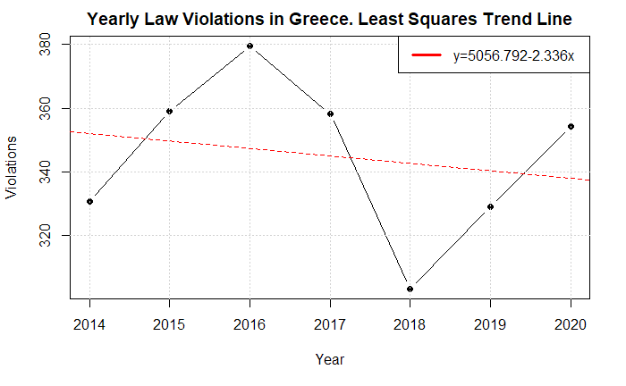

```r
abline(a=b_0,b=b_1,lty=2,col='red')
legend("topright",c("y=5056.792-2.336x"),col=c("red"), lwd=3)
```

## Άσκηση 2

Στον παρακάτω πίνακα παρουσιάζεται ο αριθμός των θανατηφόρων ατυχημάτων από το 2012 μέχρι το 2019. Να προσδιοριστεί η εξίσωση της τάσης με τη μέθοδο της ευθείας ελαχίστων τετραγώνων

```
  [,1] [,2] [,3] [,4] [,5] [,6] [,7] [,8]
x 2012 2013 2014 2015 2016 2017 2018 2019
y  190  185  195  180  200  185  190  205
```

Λύση

Οι συντελεστές της ευθείας ελαχίστων τετραγώνων φαίνονται παρακάτω :

```r
model<-lm(y~x)
model
```

```
Call:
lm(formula = y ~ x)

Coefficients:
(Intercept)            x
  -2688.036        1.429
```

Η ευθεία ελαχίστων τετραγώνων (Τάση) είναι η :
$$\hat{y}=-2688.036 +1.429x$$

### Διάγραμμα

```r
plot(x,y,main='Deadly Accidents.Least Squares Trend Line',pch=16,col='black',xlab='Year',ylab='Accidents',type='b')
grid()
```

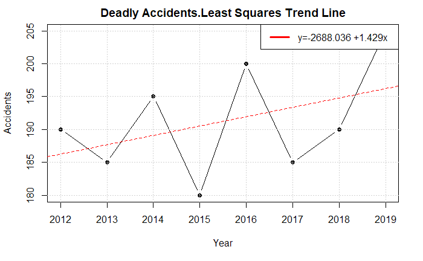

```r
abline(model,col='red',lty=2)
legend("topright",c("y=-2688.036 +1.429x"),col=c("red"), lwd=3)
```

## Επιπλέον άσκηση

## Καμπυλόγραμμη παλινδρόμηση

Να γίνει το διάγραμμα διασποράς και να βρεθεί η παραβολή ελαχίστων τετραγώνων για τα παρακάτω δεδομένα

```r
x<-seq(1,10)
y<-c(110,70,50,38,34,32,30,35,50,60)
as.matrix(rbind(x,y))
```

```
  [,1] [,2] [,3] [,4] [,5] [,6] [,7] [,8] [,9] [,10]
x    1    2    3    4    5    6    7    8    9    10
y  110   70   50   38   34   32   30   35   50    60
```

Λύση

Χρησιμοποιούμε τη μέθοδο lm() όπως και στα προηγούμενα, θέτοντας αντί για x το poly(x,2):

```r
model<-lm(y~poly(x,2))
model
```

```
Call:
lm(formula = y ~ poly(x, 2))

Coefficients:
(Intercept)  poly(x, 2)1  poly(x, 2)2
      50.90       -38.04        61.54
```

### Διάγραμμα

```r
plot(x,y,main='Polynomial regression',pch=16)
grid()
```

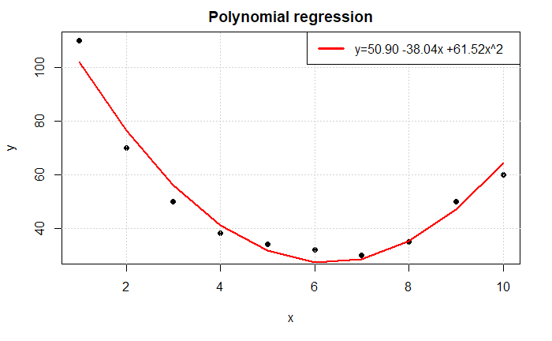

```r
pred<-predict(model)
lines(1:10, pred, lwd=2, col="red")
legend("topright",c("y=50.90 -38.04x +61.52x^2"),col=c("red"), lwd=3)
```